# Sentiment Analysis of Real-time Flipkart Product Reviews

[figure not shown]

Sentiment analysis is a natural language processing (NLP) technique used to determine the sentiment or emotional tone of a text, such as a review, tweet, or customer feedback. It involves analyzing the words and phrases in the text to classify it as positive, negative, or neutral. Sentiment analysis can be performed using various algorithms, including rule-based systems, machine learning models, and deep learning techniques.

Here are the key steps involved in sentiment analysis:

1. **Data Collection:** Gather the text data that you want to analyze. This could be in the form of customer reviews, social media posts, surveys, or any other text-based source.
2. **Preprocessing:** Clean and preprocess the text data to remove noise and irrelevant information. This step typically involves tokenization (breaking text into words or sentences), lowercasing, removing stopwords (common words like "the," "is," "and"), stemming or lemmatization (reducing words to their base form), and handling special characters or emojis.
3. **Feature Extraction:** Convert the preprocessed text into numerical features that can be used by machine learning models. Common techniques for feature extraction in sentiment analysis include bag-of-words (BoW), term frequency-inverse document frequency (TF-IDF), word embeddings (such as Word2Vec or GloVe), and n-grams.
4. **Sentiment Classification:** Train a machine learning or deep learning model on labeled data (data with sentiment labels like positive, negative, or neutral) to classify the sentiment of new, unseen text. Popular algorithms for sentiment classification include Support Vector Machines (SVM), Naive Bayes, Logistic Regression, Random Forest, and deep learning architectures like Recurrent Neural Networks (RNNs) or Convolutional Neural Networks (CNNs).
5. **Evaluation:** Evaluate the performance of your sentiment analysis model using metrics such as accuracy, precision, recall, F1-score, or confusion matrix. This helps assess how well the model is performing in predicting sentiment.
6. **Deployment:** Once the sentiment analysis model is trained and evaluated satisfactorily, deploy it in production to analyze real-time or batch text data and extract sentiment insights.

## IMPORTING DATASET

#### Web Scraping Customer Reviews from Flipkart

##### Problem Statement

In today's data-driven world, customer feedback and reviews play a crucial role in shaping purchasing decisions. As data scientists, it's essential to be proficient in extracting and analyzing customer sentiments from online platforms. Flipkart, one of India's leading e-commerce giants, hosts a diverse range of products with a wealth of customer feedback.

##### Objective

The objective of this assignment is to develop web scraping skills by extracting customer reviews from the Flipkart website. This exercise will provide you with practical experience in accessing and parsing web content, handling pagination, and structuring data for analysis.

##### Task

Your task is to write a Python script that automates the process of extracting customer reviews for a specific product category on the Flipkart website. This script should be capable of efficiently retrieving reviews from multiple pages and storing them in a structured format for further analysis.

##### Extract the following information:

- Reviewer Name
- Reviewer Rating
- Review Title
- Review Text
- Place of Review
- Date of Review
- Up Votes
- Down Votes

```python
import pandas as pd
df_badminton = pd.read_csv(r"C:\Users\pamar\Downloads\New folder\reviews_data_dump\reviews_badminton\data.csv")
```

```python
df_badminton.head()
```

|  | Reviewer Name | Review Title | Place of Review | Up Votes | Down Votes | Month | Review text | Ratings |
| --- | --- | --- | --- | --- | --- | --- | --- | --- |
| 0 | Kamal Suresh | Nice product | Certified Buyer, Chirakkal | 889.0 | 64.0 | Feb 2021 | Nice product, good quality, but price is now r... | 4 |
| 1 | Flipkart Customer | Don't waste your money | Certified Buyer, Hyderabad | 109.0 | 6.0 | Feb 2021 | They didn't supplied Yonex Mavis 350. Outside ... | 1 |
| 2 | A. S. Raja Srinivasan | Did not meet expectations | Certified Buyer, Dharmapuri | 42.0 | 3.0 | Apr 2021 | Worst product. Damaged shuttlecocks packed in ... | 1 |
| 3 | Suresh Narayanasamy | Fair | Certified Buyer, Chennai | 25.0 | 1.0 | NaN | Quite O. K. , but nowadays the quality of the... | 3 |
| 4 | ASHIK P A | Over priced | NaN | 147.0 | 24.0 | Apr 2016 | Over pricedJust â?¹620 ..from retailer.I didn'... | 1 |

```python
df_badminton.columns = df_badminton.columns.str.upper()
```

```python
df_badminton.columns
```

```
Index(['REVIEWER NAME', 'REVIEW TITLE', 'PLACE OF REVIEW', 'UP VOTES',
       'DOWN VOTES', 'MONTH', 'REVIEW TEXT', 'RATINGS'],
      dtype='object')
```

```python
df_badminton = df_badminton[['REVIEWER NAME', 'REVIEW TITLE', 'PLACE OF REVIEW', 'UP VOTES', 'DOWN VOTES', 'MONTH','REVIEW TEXT', 'RATINGS']]
df_badminton.columns = ['REVIEWER_NAME', 'REVIEW_TITLE', 'PLACE_OF_REVIEW', 'UP_VOTES', 'DOWN_VOTES', 'DATE_OF_REVIEW', 'REVIEW_TEXT', 'REVIEWER_RATING']
```

```python
df_badminton.columns
```

```
Index(['REVIEWER_NAME', 'REVIEW_TITLE', 'PLACE_OF_REVIEW', 'UP_VOTES',
       'DOWN_VOTES', 'DATE_OF_REVIEW', 'REVIEW_TEXT', 'REVIEWER_RATING'],
      dtype='object')
```

```python
df_rvw=df_badminton
```

```python
df_rvw.info()
```

```
<class 'pandas.core.frame.DataFrame'>
RangeIndex: 8518 entries, 0 to 8517
Data columns (total 8 columns):
 #   Column           Non-Null Count  Dtype
---  ------           --------------  -----
 0   REVIEWER_NAME    8508 non-null   object
 1   REVIEW_TITLE     8508 non-null   object
 2   PLACE_OF_REVIEW  8468 non-null   object
 3   UP_VOTES         8508 non-null   float64
 4   DOWN_VOTES       8508 non-null   float64
 5   DATE_OF_REVIEW   8053 non-null   object
 6   REVIEW_TEXT      8510 non-null   object
 7   REVIEWER_RATING  8518 non-null   int64
dtypes: float64(2), int64(1), object(5)
memory usage: 532.5+ KB
```

### Reviewer Name:

- This attribute represents the name or username of the reviewer who wrote the review on Flipkart. It identifies the individual or entity behind the review.

### Reviewer Rating:

- The reviewer rating indicates the rating or score given by the reviewer to the product or service they are reviewing. Ratings are typically on a scale, such as 1 to 5 stars, where higher ratings indicate more positive reviews and lower ratings indicate negative or less favorable reviews.

### Review Title:

- This attribute contains the title or heading of the review provided by the reviewer. The review title often summarizes the main point or sentiment of the review in a concise manner.

### Review Text:

- The review text is the main content of the review. It includes the detailed description, opinions, experiences, feedback, and any other information that the reviewer wants to share about their experience with the product or service.

### Date of Review:

- The date of review indicates when the review was posted or written by the reviewer. It provides a timestamp for when the review was made, allowing for chronological analysis of reviews over time.

### Up Votes:

- Up votes represent the number of positive or favorable votes or likes given to the review by other users or readers. Up votes are a form of validation or agreement with the content of the review.

### Down Votes:

- Down votes, on the other hand, indicate the number of negative or unfavorable votes or dislikes received by the review. Down votes represent disagreement or dissatisfaction with the review content.

## DATA PRE-PROCESSING

```python
df_rvw['DATE_OF_REVIEW'] = pd.to_datetime(df_rvw['DATE_OF_REVIEW'], errors='coerce')
```

```python
df_rvw['MONTH'] = df_rvw['DATE_OF_REVIEW'].dt.month_name()
df_rvw['YEAR'] = df_rvw['DATE_OF_REVIEW'].dt.year
```

```python
print(df_rvw['YEAR'].value_counts())
print(df_rvw['MONTH'].value_counts())
```

```
2020.0    1918
2021.0    1774
2018.0    1606
2019.0    1356
2017.0     782
2022.0     561
2016.0      54
2015.0       2
Name: YEAR, dtype: int64
October      847
December     774
January      747
November     683
March        674
May          659
February     638
August       631
September    631
June         621
July         621
April        527
Name: MONTH, dtype: int64
```

```python
from sklearn.impute import SimpleImputer
import pandas as pd

# Assuming df_rvw is your DataFrame with 'YEAR' and 'MONTH' columns
# Create an instance of SimpleImputer for categorical data with 'most_frequent' strategy
imputer_categorical = SimpleImputer(strategy='most_frequent')

# Fit and transform the imputer for 'MONTH' column
df_rvw['MONTH'] = imputer_categorical.fit_transform(df_rvw[['MONTH']])

# Create an instance of SimpleImputer for numerical data with 'median' strategy
imputer_numerical = SimpleImputer(strategy='median')

# Fit and transform the imputer for 'YEAR' column
df_rvw['YEAR'] = imputer_numerical.fit_transform(df_rvw[['YEAR']])
```

```python
print(df_rvw['YEAR'].value_counts())
print(df_rvw['MONTH'].value_counts())
```

```
2020.0    2383
2021.0    1774
2018.0    1606
2019.0    1356
2017.0     782
2022.0     561
2016.0      54
2015.0       2
Name: YEAR, dtype: int64
October      1312
December      774
January       747
November      683
March         674
May           659
February      638
August        631
September     631
June          621
July          621
April         527
Name: MONTH, dtype: int64
```

```python
df_rvw.info()
```

```
<class 'pandas.core.frame.DataFrame'>
RangeIndex: 8518 entries, 0 to 8517
Data columns (total 10 columns):
 #   Column           Non-Null Count  Dtype
---  ------           --------------  -----
 0   REVIEWER_NAME    8508 non-null   object
 1   REVIEW_TITLE     8508 non-null   object
 2   PLACE_OF_REVIEW  8468 non-null   object
 3   UP_VOTES         8508 non-null   float64
 4   DOWN_VOTES       8508 non-null   float64
 5   DATE_OF_REVIEW   8053 non-null   datetime64[ns]
 6   REVIEW_TEXT      8510 non-null   object
 7   REVIEWER_RATING  8518 non-null   int64
 8   MONTH            8518 non-null   object
 9   YEAR             8518 non-null   float64
dtypes: datetime64[ns](1), float64(3), int64(1), object(5)
memory usage: 665.6+ KB
```

```python
df_rvw.isnull().sum()
```

```
REVIEWER_NAME       10
REVIEW_TITLE        10
PLACE_OF_REVIEW     50
UP_VOTES            10
DOWN_VOTES          10
DATE_OF_REVIEW     465
REVIEW_TEXT          8
REVIEWER_RATING      0
MONTH                0
YEAR                 0
dtype: int64
```

```python
df_rvw.MONTH.value_counts()
```

```
October      1312
December      774
January       747
November      683
March         674
May           659
February      638
August        631
September     631
June          621
July          621
April         527
Name: MONTH, dtype: int64
```

```python
df_rvw[df_rvw["REVIEWER_NAME"].isnull()]
```

|  | REVIEWER_NAME | REVIEW_TITLE | PLACE_OF_REVIEW | UP_VOTES | DOWN_VOTES | DATE_OF_REVIEW | REVIEW_TEXT | REVIEWER_RATING | MONTH | YEAR |
| --- | --- | --- | --- | --- | --- | --- | --- | --- | --- | --- |
| 8508 | NaN | NaN | NaN | NaN | NaN | NaT | No complaints about the item . Its the best on... | 5 | October | 2020.0 |
| 8509 | NaN | NaN | NaN | NaN | NaN | NaT | Not sure why we have charged for this product ... | 1 | October | 2020.0 |
| 8510 | NaN | NaN | NaN | NaN | NaN | NaT | NaN | 1 | October | 2020.0 |
| 8511 | NaN | NaN | NaN | NaN | NaN | NaT | NaN | 1 | October | 2020.0 |
| 8512 | NaN | NaN | NaN | NaN | NaN | NaT | NaN | 2 | October | 2020.0 |
| 8513 | NaN | NaN | NaN | NaN | NaN | NaT | NaN | 5 | October | 2020.0 |
| 8514 | NaN | NaN | NaN | NaN | NaN | NaT | NaN | 2 | October | 2020.0 |
| 8515 | NaN | NaN | NaN | NaN | NaN | NaT | NaN | 4 | October | 2020.0 |
| 8516 | NaN | NaN | NaN | NaN | NaN | NaT | NaN | 1 | October | 2020.0 |
| 8517 | NaN | NaN | NaN | NaN | NaN | NaT | NaN | 4 | October | 2020.0 |

```python
df_rvw = df_rvw.dropna(subset=["REVIEWER_NAME"])
```

```python
df_rvw[df_rvw['PLACE_OF_REVIEW']=="Certified Buyer"].value_counts().sum()
```

```
26
```

```python
df_rvw[df_rvw["PLACE_OF_REVIEW"].isnull()]
```

|  | REVIEWER_NAME | REVIEW_TITLE | PLACE_OF_REVIEW | UP_VOTES | DOWN_VOTES | DATE_OF_REVIEW | REVIEW_TEXT | REVIEWER_RATING | MONTH | YEAR |
| --- | --- | --- | --- | --- | --- | --- | --- | --- | --- | --- |
| 4 | ASHIK P A | Over priced | NaN | 147.0 | 24.0 | 2016-04-01 | Over pricedJust â?¹620 ..from retailer.I didn'... | 1 | April | 2016.0 |
| 265 | sreejith ncm | Above-average product | NaN | 3.0 | 1.0 | 2016-10-01 | Good, but flipcart price is too high. From the... | 3 | October | 2016.0 |
| 271 | Deepak Bunde | Cheating | NaN | 1.0 | 1.0 | 2016-12-01 | You are fleecing customers by tagging wrong MR... | 1 | December | 2016.0 |
| 285 | Adhil S | Decent product | NaN | 1.0 | 0.0 | 2016-12-01 | Product is good but price is increased ... | 3 | December | 2016.0 |
| 287 | Proprietor Sannidhi | Brilliant | NaN | 2.0 | 2.0 | 2016-08-01 | Best cicks,but price was very highest please t... | 5 | August | 2016.0 |
| 8263 | Flipkart Customer | Fabulous! | NaN | 0.0 | 0.0 | 2017-05-01 | Good quality product i liked itREAD MORE | 5 | May | 2017.0 |
| 8321 | Flipkart Customer | Good choice | NaN | 0.0 | 0.0 | 2017-04-01 | Excellent delivery from flipkart. Authentic pr... | 5 | April | 2017.0 |
| 8322 | Flipkart Customer | Best in the market! | NaN | 0.0 | 0.0 | 2017-04-01 | Delivered in a day and at best price. Happy to... | 5 | April | 2017.0 |
| 8333 | suresh kasi | Nice product | NaN | 0.0 | 0.0 | 2017-04-01 | Great productREAD MORE | 4 | April | 2017.0 |
| 8343 | Aditya Singh | about ekart logistics | NaN | 0.0 | 0.0 | 2017-03-01 | These shuttle r d best among d available for o... | 4 | March | 2017.0 |
| 8348 | Nithin E P | Super! | NaN | 0.0 | 1.0 | 2017-03-01 | very quality product supeer 5starREAD MORE | 5 | March | 2017.0 |
| 8364 | Prabakaran R | Don't waste your money | NaN | 0.0 | 1.0 | 2017-03-01 | ExcellentREAD MORE | 5 | March | 2017.0 |
| 8369 | Bagadi ganapathi Rao | Mind-blowing purchase | NaN | 0.0 | 0.0 | 2017-03-01 | goodREAD MORE | 4 | March | 2017.0 |
| 8372 | Debjeet Barman | Nice shuttle | NaN | 0.0 | 0.0 | 2017-03-01 | The shuttle s very slow not up to the mark. Wa... | 1 | March | 2017.0 |
| 8381 | Flipkart Customer | Excellent | NaN | 0.0 | 0.0 | 2017-02-01 | SuperREAD MORE | 5 | February | 2017.0 |
| 8399 | Nikhil Kamble | Nice product | NaN | 0.0 | 0.0 | 2017-01-01 | Good product for proffesional players long las... | 5 | January | 2017.0 |
| 8413 | Sushil Gupta | Really Nice | NaN | 0.0 | 0.0 | 2016-11-01 | Good shuttleREAD MORE | 5 | November | 2016.0 |
| 8426 | surendra lahare | Unsatisfactory | NaN | 3.0 | 0.0 | 2017-01-01 | Good quality shuttlecocksQuite impressiveREAD ... | 5 | January | 2017.0 |
| 8427 | Flipkart Customer | Horrible | NaN | 2.0 | 0.0 | 2016-12-01 | Very good shuttle cocksREAD MORE | 5 | December | 2016.0 |
| 8428 | Ashik p | Don't waste your money | NaN | 2.0 | 0.0 | 2016-09-01 | It was good but not durable ! It was good to p... | 4 | September | 2016.0 |
| 8429 | Flipkart Customer | Useless product | NaN | 2.0 | 1.0 | 2017-03-01 | Some of the shuttle were wear out ....didn't e... | 3 | March | 2017.0 |
| 8434 | Richu Nagpal | Worthless | NaN | 1.0 | 0.0 | 2016-12-01 | Original, sealed nice product .Go for it . Fli... | 5 | December | 2016.0 |
| 8436 | Nishitha Rout | Decent product | NaN | 1.0 | 1.0 | 2016-11-01 | Don't buy fraud seller ...MRP is 890 then how... | 1 | November | 2016.0 |
| 8437 | Flipkart Customer | Value-for-money | NaN | 1.0 | 1.0 | 2016-09-01 | Rate is too high. In local market we are getti... | 1 | September | 2016.0 |
| 8477 | Sanjay Kumar | Worth every penny | NaN | 0.0 | 0.0 | 2017-03-01 | fake product. You will not get the orginal spe... | 1 | March | 2017.0 |
| 8482 | Sriram Ramachandran | Could be way better | NaN | 0.0 | 0.0 | 2017-02-01 | Super fast deliveryREAD MORE | 5 | February | 2017.0 |
| 8486 | Vasu | Worthless | NaN | 0.0 | 0.0 | 2017-01-01 | Shuttle is perfect and seems to be durable but... | 5 | January | 2017.0 |
| 8487 | shibin joseph | Useless product | NaN | 0.0 | 0.0 | 2016-12-01 | I will received my order into fix timeREAD MORE | 5 | December | 2016.0 |
| 8488 | Shashikant Kumar | Hated it! | NaN | 0.0 | 0.0 | 2016-12-01 | Good product.. excellent service from Flipkart... | 5 | December | 2016.0 |
| 8490 | Flipkart Customer | Very Good | NaN | 0.0 | 0.0 | 2016-11-01 | Poor customer service. The delivery boy can't ... | 1 | November | 2016.0 |
| 8491 | Pallab jyoti Saikia | Very poor | NaN | 0.0 | 0.0 | 2016-11-01 | Late dileveryREAD MORE | 1 | November | 2016.0 |
| 8492 | SHIVA KRISHNA | Over priced product | NaN | 0.0 | 0.0 | 2016-11-01 | Box damagedREAD MORE | 2 | November | 2016.0 |
| 8498 | Dr ArunPrasannan | Over priced | NaN | 0.0 | 0.0 | 2016-03-01 | Over priced, flipkart please checkREAD MORE | 1 | March | 2016.0 |
| 8500 | Narayana KNVL | Inflated price and offering discount | NaN | 0.0 | 0.0 | 2015-12-01 | Over pricedREAD MORE | 4 | December | 2015.0 |
| 8501 | Amit Dashore | discount? lol! | NaN | 5.0 | 0.0 | 2016-07-01 | Haamaare yaha local market main yahi shuttle..... | 1 | July | 2016.0 |
| 8502 | Sreekesh Kamath | Costly on flipkart | NaN | 15.0 | 9.0 | 2016-08-01 | You will get this product at around 600 to 650... | 2 | August | 2016.0 |
| 8503 | darwin | Yones Mavis 350 Blue cap | NaN | 2.0 | 0.0 | 2016-04-01 | Wrost and duplicate productDon't buy this sell... | 1 | April | 2016.0 |
| 8504 | naresh g | For Mavis350 | NaN | 2.0 | 1.0 | 2016-08-01 | Received product intact and sealedREAD MORE | 5 | August | 2016.0 |
| 8505 | MD. Jabbar | Very Good | NaN | 1.0 | 0.0 | 2016-09-01 | Delivered before time but price is high from m... | 3 | September | 2016.0 |
| 8506 | Abani Behera | Don't waste your money | NaN | 0.0 | 2.0 | 2016-09-01 | up to the mark but same is available in market... | 4 | September | 2016.0 |

```python
df_rvw['CB_PLACE_OF_REVIEW'] = df_rvw['PLACE_OF_REVIEW'].str.split(', ', expand=True)[1]

# Fill null values with None
df_rvw['CB_PLACE_OF_REVIEW'] = df_rvw['CB_PLACE_OF_REVIEW'].fillna('Others')
```

```python
df_rvw.isnull().sum()
```

```
REVIEWER_NAME           0
REVIEW_TITLE            0
PLACE_OF_REVIEW        40
UP_VOTES                0
DOWN_VOTES              0
DATE_OF_REVIEW        455
REVIEW_TEXT             0
REVIEWER_RATING         0
MONTH                   0
YEAR                    0
CB_PLACE_OF_REVIEW      0
dtype: int64
```

```python
columns_to_drop = ['PLACE_OF_REVIEW', 'DATE_OF_REVIEW']
df_rvw = df_rvw.drop(columns=columns_to_drop)
```

```python
# Define thresholds for categorization
positive_threshold = 3
negative_threshold = 2

df_rvw['SENTIMENT'] = pd.cut(df_rvw['REVIEWER_RATING'], bins=[-float('inf'), negative_threshold, float('inf')],
                              labels=['Negative', 'Positive'], include_lowest=True)
```

```python
df_rvw.head()
```

|  | REVIEWER_NAME | REVIEW_TITLE | UP_VOTES | DOWN_VOTES | REVIEW_TEXT | REVIEWER_RATING | MONTH | YEAR | CB_PLACE_OF_REVIEW | SENTIMENT |
| --- | --- | --- | --- | --- | --- | --- | --- | --- | --- | --- |
| 0 | Kamal Suresh | Nice product | 889.0 | 64.0 | Nice product, good quality, but price is now r... | 4 | February | 2021.0 | Chirakkal | Positive |
| 1 | Flipkart Customer | Don't waste your money | 109.0 | 6.0 | They didn't supplied Yonex Mavis 350. Outside ... | 1 | February | 2021.0 | Hyderabad | Negative |
| 2 | A. S. Raja Srinivasan | Did not meet expectations | 42.0 | 3.0 | Worst product. Damaged shuttlecocks packed in ... | 1 | April | 2021.0 | Dharmapuri | Negative |
| 3 | Suresh Narayanasamy | Fair | 25.0 | 1.0 | Quite O. K. , but nowadays the quality of the... | 3 | October | 2020.0 | Chennai | Positive |
| 4 | ASHIK P A | Over priced | 147.0 | 24.0 | Over pricedJust â?¹620 ..from retailer.I didn'... | 1 | April | 2016.0 | Others | Negative |

```python
df_rvw["REVIEW_TEXT"][2]
```

```
"Worst product. Damaged shuttlecocks packed in new box. It's not a original yonex product. Don't buy.flipkart platform is chosen to fraud the buyers.READ MORE"
```

```python
print("#"*50)
print(df_rvw.REVIEWER_NAME.value_counts().head(10))
print("#"*50)
print(df_rvw.REVIEW_TITLE.value_counts().head(20))
print("#"*50)
print(df_rvw.CB_PLACE_OF_REVIEW.value_counts().head(20))
print("#"*50)
print(df_rvw.SENTIMENT.value_counts())
```

```
##################################################
Flipkart Customer    2098
My Account             11
Praveen Kumar           6
Rajesh Kumar            5
Santhosh Kumar          5
Naveen Kumar            5
Pavan Kumar             4
Pradeep Kumar           4
Deepak Kumar            4
Manish Kumar            4
Name: REVIEWER_NAME, dtype: int64
##################################################
Wonderful                416
Brilliant                303
Classy product           299
Excellent                298
Perfect product!         295
Terrific                 291
Best in the market!      289
Highly recommended       287
Must buy!                281
Just wow!                276
Awesome                  274
Simply awesome           270
Fabulous!                267
Great product            267
Mind-blowing purchase    267
Terrific purchase        259
Worth every penny        253
Super!                   249
Good choice              186
Delightful               182
Name: REVIEW_TITLE, dtype: int64
##################################################
Bengaluru                 319
Hyderabad                 251
Chennai                   240
Bangalore                 212
New Delhi                 155
Visakhapatnam             109
Pune                       84
Others                     66
Mumbai                     56
Lucknow                    55
East Godavari District     51
Visakhapatnam District     44
Thiruvananthapuram         44
Kollam District            36
West Godavari District     36
Coimbatore                 36
Vizianagaram District      35
Ghaziabad                  34
Chittoor District          32
Vellore                    30
Name: CB_PLACE_OF_REVIEW, dtype: int64
##################################################
Positive    7437
Negative    1071
Name: SENTIMENT, dtype: int64
```

```python
df_rvw.info()
```

```
<class 'pandas.core.frame.DataFrame'>
Int64Index: 8508 entries, 0 to 8507
Data columns (total 10 columns):
 #   Column              Non-Null Count  Dtype
---  ------              --------------  -----
 0   REVIEWER_NAME       8508 non-null   object
 1   REVIEW_TITLE        8508 non-null   object
 2   UP_VOTES            8508 non-null   float64
 3   DOWN_VOTES          8508 non-null   float64
 4   REVIEW_TEXT         8508 non-null   object
 5   REVIEWER_RATING     8508 non-null   int64
 6   MONTH               8508 non-null   object
 7   YEAR                8508 non-null   float64
 8   CB_PLACE_OF_REVIEW  8508 non-null   object
 9   SENTIMENT           8508 non-null   category
dtypes: category(1), float64(3), int64(1), object(5)
memory usage: 931.2+ KB
```

```python
print("#"*50)
print(df_rvw.UP_VOTES.value_counts())
print("#"*50)
print(df_rvw.DOWN_VOTES.value_counts())
print("#"*50)
print(df_rvw.MONTH.value_counts())
print("#"*50)
print(df_rvw.YEAR.value_counts())
```

```
##################################################
0.0      8283
1.0       125
2.0        33
3.0        17
4.0        10
5.0         4
14.0        3
8.0         2
22.0        2
6.0         2
17.0        1
124.0       1
24.0        1
11.0        1
216.0       1
9.0         1
7.0         1
19.0        1
13.0        1
889.0       1
12.0        1
30.0        1
109.0       1
81.0        1
71.0        1
23.0        1
142.0       1
146.0       1
57.0        1
50.0        1
59.0        1
403.0       1
173.0       1
147.0       1
25.0        1
42.0        1
15.0        1
Name: UP_VOTES, dtype: int64
##################################################
```

[output cut: 35 more lines]

```
September     631
June          621
July          621
April         527
Name: MONTH, dtype: int64
##################################################
2020.0    2373
2021.0    1774
2018.0    1606
2019.0    1356
2017.0     782
2022.0     561
2016.0      54
2015.0       2
Name: YEAR, dtype: int64
```

```python
df_rvw.select_dtypes(include='number')
```

|  | UP_VOTES | DOWN_VOTES | REVIEWER_RATING | YEAR |
| --- | --- | --- | --- | --- |
| 0 | 889.0 | 64.0 | 4 | 2021.0 |
| 1 | 109.0 | 6.0 | 1 | 2021.0 |
| 2 | 42.0 | 3.0 | 1 | 2021.0 |
| 3 | 25.0 | 1.0 | 3 | 2020.0 |
| 4 | 147.0 | 24.0 | 1 | 2016.0 |
| ... | ... | ... | ... | ... |
| 8503 | 2.0 | 0.0 | 1 | 2016.0 |
| 8504 | 2.0 | 1.0 | 5 | 2016.0 |
| 8505 | 1.0 | 0.0 | 3 | 2016.0 |
| 8506 | 0.0 | 2.0 | 4 | 2016.0 |
| 8507 | 0.0 | 1.0 | 5 | 2016.0 |

8508 rows × 4 columns

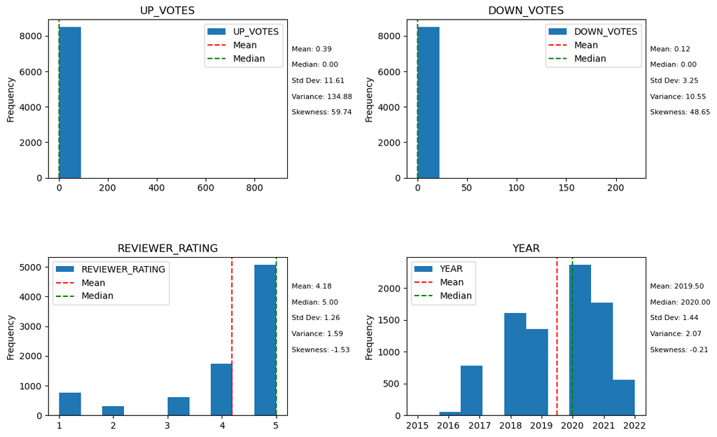

```python
import matplotlib.pyplot as plt

# Filter numeric columns from the DataFrame
numeric_columns = df_rvw.select_dtypes(include='number').columns

# Calculate statistics for each numeric column
statistics = df_rvw[numeric_columns].describe()

# Plot the histograms with subplots
fig, axes = plt.subplots(2, 2, figsize=(12, 8))
plt.subplots_adjust(wspace=0.5, hspace=0.5)

for i, column in enumerate(numeric_columns):
    ax = axes[i // 2, i % 2]
    df_rvw[column].plot(kind='hist', ax=ax)
    ax.set_title(column)

    # Add vertical lines for mean and median
    ax.axvline(x=statistics.loc['mean', column], color='r', linestyle='--', label='Mean')
    ax.axvline(x=statistics.loc['50%', column], color='g', linestyle='--', label='Median')

    # Add text labels for statistics outside the plot
    ax.text(1.02, 0.8, f"Mean: {statistics.loc['mean', column]:.2f}", transform=ax.transAxes, fontsize=8)
    ax.text(1.02, 0.7, f"Median: {statistics.loc['50%', column]:.2f}", transform=ax.transAxes, fontsize=8)
    ax.text(1.02, 0.6, f"Std Dev: {statistics.loc['std', column]:.2f}", transform=ax.transAxes, fontsize=8)
    ax.text(1.02, 0.5, f"Variance: {statistics.loc['std', column]**2:.2f}", transform=ax.transAxes, fontsize=8)
    ax.text(1.02, 0.4, f"Skewness: {df_rvw[column].skew():.2f}", transform=ax.transAxes, fontsize=8)

    ax.legend()

plt.show()
```

## EDA

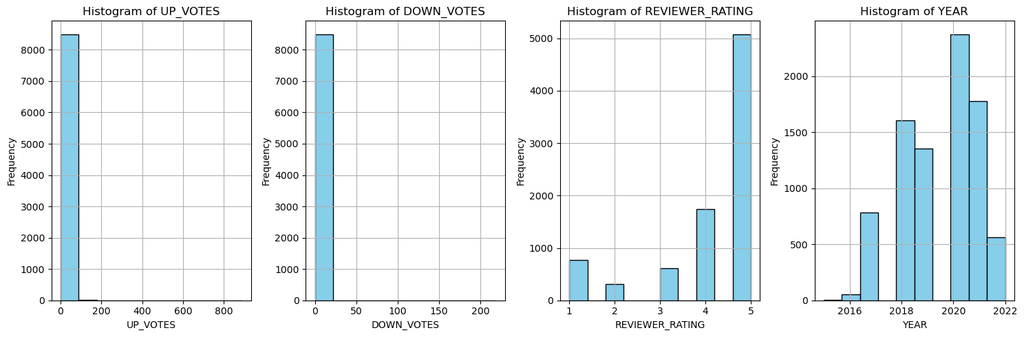

```python
import matplotlib.pyplot as plt

# Select numerical columns
numeric_columns = df_rvw.select_dtypes(include='number')

# Create subplots
fig, axes = plt.subplots(1, 4, figsize=(15, 5))

# Plot histograms for each numerical columna
for i, column in enumerate(numeric_columns.columns):
    ax = axes[i]
    ax.hist(numeric_columns[column], bins=10, color='skyblue', edgecolor='black')
    ax.set_title(f'Histogram of {column}')
    ax.set_xlabel(column)
    ax.set_ylabel('Frequency')
    ax.grid(True)

# Adjust layout and display plot
plt.tight_layout()
plt.show()
```

```python
import plotly.express as px

# Get the value counts for the 'CB_PLACE_OF_REVIEW' column
place_counts = df_rvw['MONTH'].value_counts()

# Create a Plotly bar plot
fig = px.bar(place_counts,
             x=place_counts.index,
             y=place_counts.values,
             labels={'x': 'MONTH', 'y': 'Count'},
             title='MONTH COUNT',
             color=place_counts.index,  # Each bar has a distinct color
             color_discrete_sequence=px.colors.qualitative.Plotly)

fig.update_xaxes(tickangle=45)  # Rotate x-axis labels for better readability
fig.show()
```

[interactive chart not shown]

```python
sentiment_cross_tab = pd.crosstab(index=[df_rvw['YEAR'], df_rvw['SENTIMENT']], columns=df_rvw['MONTH'], margins=True)

# Style the cross-tabulation DataFrame with background colors
styled_sentiment_cross_tab = sentiment_cross_tab.style.background_gradient(cmap='Blues')

# Display the styled DataFrame
styled_sentiment_cross_tab
```

| YEAR | MONTH SENTIMENT | April | August | December | February | January | July | June | March | May | November | October | September | All |
| --- | --- | --- | --- | --- | --- | --- | --- | --- | --- | --- | --- | --- | --- | --- |
| 2015.000000 | Positive | 0 | 0 | 2 | 0 | 0 | 0 | 0 | 0 | 0 | 0 | 0 | 0 | 2 |
| 2016.000000 | Negative | 2 | 1 | 1 | 0 | 0 | 1 | 0 | 1 | 0 | 6 | 2 | 1 | 15 |
|  | Positive | 0 | 3 | 9 | 0 | 0 | 0 | 0 | 0 | 0 | 6 | 15 | 6 | 39 |
| 2017.000000 | Negative | 3 | 3 | 14 | 2 | 0 | 1 | 5 | 13 | 13 | 10 | 16 | 5 | 85 |
|  | Positive | 53 | 58 | 96 | 17 | 17 | 11 | 12 | 46 | 81 | 83 | 81 | 142 | 697 |
| 2018.000000 | Negative | 15 | 10 | 34 | 14 | 9 | 7 | 10 | 16 | 6 | 29 | 25 | 10 | 185 |
|  | Positive | 112 | 86 | 189 | 91 | 111 | 94 | 108 | 116 | 109 | 160 | 162 | 83 | 1421 |
| 2019.000000 | Negative | 7 | 8 | 29 | 20 | 26 | 5 | 7 | 11 | 8 | 11 | 12 | 10 | 154 |
|  | Positive | 98 | 78 | 114 | 124 | 162 | 79 | 76 | 112 | 99 | 84 | 108 | 68 | 1202 |
| 2020.000000 | Negative | 0 | 18 | 33 | 13 | 30 | 16 | 14 | 12 | 5 | 33 | 103 | 14 | 291 |
|  | Positive | 3 | 190 | 139 | 120 | 119 | 204 | 170 | 80 | 117 | 165 | 589 | 186 | 2082 |
| 2021.000000 | Negative | 31 | 12 | 29 | 25 | 32 | 15 | 15 | 27 | 15 | 13 | 9 | 8 | 231 |
|  | Positive | 157 | 127 | 85 | 135 | 141 | 139 | 162 | 178 | 147 | 79 | 114 | 79 | 1543 |
| 2022.000000 | Negative | 12 | 9 | 0 | 12 | 22 | 8 | 6 | 16 | 12 | 0 | 10 | 3 | 110 |
|  | Positive | 34 | 28 | 0 | 65 | 78 | 41 | 36 | 46 | 47 | 4 | 56 | 16 | 451 |
| All |  | 527 | 631 | 774 | 638 | 747 | 621 | 621 | 674 | 659 | 683 | 1302 | 631 | 8508 |

```python
import pandas as pd

# Get the top 20 places of review based on value counts
top_places = df_rvw['CB_PLACE_OF_REVIEW'].value_counts().head(20).index

# Filter the DataFrame based on the top places
filtered_df = df_rvw[df_rvw['CB_PLACE_OF_REVIEW'].isin(top_places)]

# Create a cross-tabulation (crosstab) to count sentiments for each month and top places
sentiment_cross_tab = pd.crosstab(index=[filtered_df['CB_PLACE_OF_REVIEW'], filtered_df['SENTIMENT']],
                                   columns=filtered_df['MONTH'],
                                   margins=True)

# Style the cross-tabulation DataFrame with background colors
styled_sentiment_cross_tab = sentiment_cross_tab.style.background_gradient(cmap='Blues')

# Display the styled DataFrame
styled_sentiment_cross_tab
```

| CB_PLACE_OF_REVIEW | MONTH SENTIMENT | April | August | December | February | January | July | June | March | May | November | October | September | All |
| --- | --- | --- | --- | --- | --- | --- | --- | --- | --- | --- | --- | --- | --- | --- |
| Bangalore | Negative | 2 | 1 | 0 | 4 | 5 | 3 | 2 | 1 | 3 | 5 | 4 | 5 | 35 |
|  | Positive | 11 | 17 | 17 | 12 | 16 | 12 | 8 | 13 | 28 | 7 | 23 | 13 | 177 |
| Bengaluru | Negative | 1 | 1 | 2 | 4 | 6 | 3 | 0 | 5 | 3 | 3 | 9 | 2 | 39 |
|  | Positive | 16 | 22 | 18 | 17 | 21 | 31 | 20 | 23 | 21 | 23 | 47 | 21 | 280 |
| Chennai | Negative | 4 | 3 | 1 | 2 | 1 | 2 | 0 | 3 | 1 | 2 | 9 | 1 | 29 |
|  | Positive | 14 | 20 | 13 | 15 | 12 | 13 | 17 | 18 | 14 | 15 | 44 | 16 | 211 |
| Chittoor District | Negative | 1 | 0 | 1 | 0 | 1 | 0 | 0 | 0 | 1 | 1 | 1 | 0 | 6 |
|  | Positive | 3 | 2 | 1 | 2 | 3 | 1 | 2 | 0 | 3 | 2 | 3 | 4 | 26 |
| Coimbatore | Negative | 2 | 1 | 1 | 0 | 0 | 0 | 0 | 1 | 0 | 2 | 3 | 0 | 10 |
|  | Positive | 0 | 4 | 3 | 2 | 2 | 1 | 1 | 5 | 3 | 1 | 2 | 2 | 26 |
| East Godavari District | Negative | 0 | 1 | 0 | 0 | 1 | 2 | 0 | 0 | 1 | 0 | 1 | 0 | 6 |
|  | Positive | 1 | 6 | 0 | 2 | 0 | 8 | 5 | 6 | 6 | 3 | 6 | 2 | 45 |
| Ghaziabad | Negative | 0 | 0 | 2 | 1 | 0 | 1 | 1 | 2 | 0 | 1 | 0 | 0 | 8 |
|  | Positive | 0 | 3 | 0 | 1 | 0 | 2 | 6 | 0 | 3 | 3 | 3 | 5 | 26 |
| Hyderabad | Negative | 2 | 3 | 6 | 5 | 1 | 0 | 2 | 2 | 5 | 4 | 5 | 0 | 35 |
|  | Positive | 12 | 15 | 13 | 14 | 13 | 18 | 16 | 23 | 21 | 21 | 32 | 18 | 216 |
| Kollam District | Negative | 1 | 0 | 0 | 0 | 0 | 1 | 1 | 0 | 2 | 2 | 0 | 0 | 7 |
|  | Positive | 0 | 4 | 3 | 2 | 2 | 4 | 1 | 2 | 4 | 0 | 3 | 4 | 29 |
| Lucknow | Negative | 1 | 0 | 0 | 0 | 0 | 0 | 2 | 1 | 0 | 0 | 1 | 0 | 5 |
|  | Positive | 4 | 3 | 6 | 2 | 2 | 3 | 3 | 2 | 8 | 5 | 8 | 4 | 50 |
| Mumbai | Negative | 0 | 0 | 2 | 0 | 1 | 0 | 0 | 1 | 1 | 0 | 2 | 0 | 7 |
|  | Positive | 4 | 2 | 2 | 4 | 7 | 4 | 3 | 5 | 6 | 2 | 6 | 4 | 49 |
| New Delhi | Negative | 0 | 2 | 2 | 3 | 1 | 0 | 0 | 1 | 2 | 1 | 3 | 0 | 15 |
|  | Positive | 12 | 12 | 14 | 9 | 18 | 10 | 7 | 6 | 6 | 10 | 21 | 15 | 140 |
| Others | Negative | 2 | 3 | 1 | 0 | 0 | 1 | 0 | 3 | 0 | 6 | 2 | 1 | 19 |
|  | Positive | 5 | 6 | 6 | 3 | 4 | 3 | 0 | 6 | 2 | 1 | 5 | 6 | 47 |
| Pune | Negative | 1 | 0 | 2 | 1 | 1 | 0 | 1 | 2 | 0 | 2 | 1 | 1 | 12 |
|  | Positive | 6 | 4 | 6 | 8 | 6 | 2 | 8 | 7 | 3 | 6 | 5 | 11 | 72 |
| Thiruvananthapuram | Negative | 0 | 0 | 1 | 0 | 0 | 0 | 0 | 0 | 0 | 1 | 4 | 0 | 6 |
|  | Positive | 1 | 3 | 0 | 3 | 2 | 2 | 4 | 7 | 1 | 4 | 8 | 3 | 38 |
| Vellore | Negative | 0 | 0 | 1 | 1 | 1 | 0 | 0 | 0 | 0 | 0 | 1 | 0 | 4 |
|  | Positive | 1 | 0 | 2 | 1 | 5 | 4 | 1 | 0 | 3 | 0 | 4 | 5 | 26 |
| Visakhapatnam | Negative | 0 | 1 | 2 | 1 | 3 | 0 | 1 | 1 | 0 | 0 | 1 | 0 | 10 |
|  | Positive | 8 | 11 | 8 | 5 | 8 | 6 | 9 | 6 | 12 | 3 | 16 | 7 | 99 |
| Visakhapatnam District | Negative | 1 | 1 | 0 | 1 | 0 | 0 | 0 | 0 | 2 | 1 | 2 | 0 | 8 |
|  | Positive | 3 | 3 | 3 | 3 | 2 | 2 | 3 | 3 | 2 | 1 | 8 | 3 | 36 |
| Vizianagaram District | Negative | 0 | 0 | 1 | 1 | 0 | 1 | 0 | 0 | 0 | 0 | 0 | 0 | 3 |
|  | Positive | 2 | 5 | 2 | 1 | 2 | 1 | 1 | 2 | 3 | 4 | 5 | 4 | 32 |
| West Godavari District | Negative | 1 | 0 | 1 | 1 | 1 | 0 | 0 | 0 | 0 | 0 | 0 | 0 | 4 |
|  | Positive | 3 | 1 | 2 | 4 | 2 | 3 | 4 | 5 | 4 | 0 | 3 | 1 | 32 |
| All |  | 125 | 160 | 145 | 135 | 150 | 144 | 129 | 162 | 174 | 142 | 301 | 158 | 1925 |

```python
import plotly.graph_objects as go

# Top review titles
top_review_titles = df_rvw['REVIEW_TITLE'].value_counts().head(20)
# Top places of review
top_places_review = df_rvw['CB_PLACE_OF_REVIEW'].value_counts().head(20)

# Define a list of colors for each bar
colors_titles = ['blue', 'red', 'green', 'purple', 'orange', 'cyan', 'magenta', 'yellow', 'brown', 'pink',
                 'lightblue', 'lightgreen', 'lightcoral', 'lightgray', 'lightsalmon', 'lightseagreen',
                 'lightskyblue', 'lightsteelblue', 'lightyellow', 'lime']

colors_places = ['red', 'green', 'blue', 'purple', 'orange', 'cyan', 'magenta', 'yellow', 'brown', 'pink',
                 'lightblue', 'lightgreen', 'lightcoral', 'lightgray', 'lightsalmon', 'lightseagreen',
                 'lightskyblue', 'lightsteelblue', 'lightyellow', 'lime']

# Plot top review titles with different colors for each bar
fig_titles = go.Figure(go.Bar(x=top_review_titles.index, y=top_review_titles.values, marker_color=colors_titles))
fig_titles.update_layout(
    title='Top 20 Review Titles',
    xaxis_title='Review Titles',
    yaxis_title='Count',
    width=1000,
    height=600
)
fig_titles.show()

# Plot top places of review with different colors for each bar
fig_places = go.Figure(go.Bar(x=top_places_review.index, y=top_places_review.values, marker_color=colors_places))
fig_places.update_layout(
    title='Top 20 Places of Review',
    xaxis_title='Places of Review',
    yaxis_title='Count',
    width=1000,
    height=600
)
fig_places.show()
```

[interactive chart not shown]

```python
import plotly.graph_objects as go

# Get sentiment value counts
sentiment_counts = df_rvw['SENTIMENT'].value_counts()

# Create pie plot
fig = go.Figure(data=[go.Pie(labels=sentiment_counts.index, values=sentiment_counts, hole=.3,
                              marker=dict(colors=['skyblue', 'lightgreen', 'salmon']))])
fig.update_layout(title_text='Sentiment Distribution')
fig.show()
```

[interactive chart not shown]

## Reviewer Name Distribution:

- The majority of reviews are attributed to "Flipkart Customer," indicating that many reviews are anonymous or made by users without specifying their names.
- Other top reviewer names include "My Account," "Praveen Kumar," "Rajesh Kumar," "Santhosh Kumar," "Naveen Kumar," and several others, with varying frequencies of reviews. ## Review Title Sentiment:
- The most common review titles suggest overwhelmingly positive sentiments. Phrases like "Wonderful," "Brilliant," "Classy product," "Excellent," "Perfect product!," and "Terrific" dominate the titles, indicating highly positive experiences or opinions about the products.
- There are also expressions of satisfaction and recommendation such as "Highly recommended," "Must buy!," "Best in the market!," "Awesome," "Mind-blowing purchase," and "Worth every penny," among others. ## Place of Review Distribution:
- The distribution of places where reviews originated from shows a diverse range of locations.
- Cities like Bengaluru, Hyderabad, Chennai, New Delhi, Visakhapatnam, and Pune are among the top locations where reviews were made.
- Additionally, there are mentions of specific districts and areas within certain cities, reflecting a detailed breakdown of review locations. ## Sentiment Distribution:
- The sentiment analysis of the reviews indicates that the majority of reviews (7437) are classified as "Positive," while a smaller portion (1071) are categorized as "Negative."
- This suggests that the overall sentiment expressed in the reviews is predominantly positive, aligning with the positive sentiments reflected in the review titles.

## TEXT CLEANING:

- Remove Special Characters and Punctuation: Special characters and punctuation marks, such as symbols or commas, are often unnecessary for text analysis tasks. They can be removed to focus on the actual words and content of the text.
- Remove Stopwords: Stopwords are common words like "the," "is," "and," etc., that occur frequently in a language but often carry little meaning or relevance in text analysis. Removing stopwords helps reduce noise and focuses on significant words.

## Text Normalization:

- Lemmatization or Stemming: Lemmatization and stemming are techniques used to reduce words to their base or root forms.
- Lemmatization: Lemmatization involves converting words to their dictionary form or lemma. For example, "running" becomes "run," "better" becomes "good," etc.
- Stemming: Stemming reduces words to their root or stem by removing suffixes or prefixes. For example, "running" becomes "run," "better" becomes "better," etc.

```python
import nltk
from nltk.corpus import stopwords
from nltk.tokenize import word_tokenize
import string
```

```python
import nltk
nltk.download('omw-1.4')
nltk.download('stopwords')
nltk.download('wordnet')
```

```
True
```

#### Text Cleaning: Remove special characters, punctuation, and stopwords from the review text.

```python
# Text Cleaning
def clean_text(text):
    # Calculate the length before cleaning
    len_before = len(text)

    # Remove special characters and punctuation
    text = ''.join([char for char in text if char not in string.punctuation])
    # Tokenize the text
    tokens = word_tokenize(text)
    # Remove stopwords
    tokens = [word.lower() for word in tokens if word.isalpha() and word.lower() not in stopwords.words('english')]
    cleaned_text = ' '.join(tokens)

    # Calculate the length after cleaning
    len_after = len(cleaned_text)

    return cleaned_text, len_before, len_after

# Apply text cleaning and store results in new columns
df_rvw['CLEANED_TEXT'], df_rvw['LEN_BEFORE'], df_rvw['LEN_AFTER'] = zip(*df_rvw['REVIEW_TEXT'].apply(clean_text))
```

```python
df_rvw[['REVIEW_TEXT', 'CLEANED_TEXT', 'LEN_BEFORE', 'LEN_AFTER']]
```

|  | REVIEW_TEXT | CLEANED_TEXT | LEN_BEFORE | LEN_AFTER |
| --- | --- | --- | --- | --- |
| 0 | Nice product, good quality, but price is now r... | nice product good quality price rising bad sig... | 204 | 130 |
| 1 | They didn't supplied Yonex Mavis 350. Outside ... | didnt supplied yonex mavis outside cover yonex... | 118 | 83 |
| 2 | Worst product. Damaged shuttlecocks packed in ... | worst product damaged shuttlecocks packed new ... | 157 | 122 |
| 3 | Quite O. K. , but nowadays the quality of the... | quite k nowadays quality corks like years back... | 388 | 191 |
| 4 | Over pricedJust â?¹620 ..from retailer.I didn'... | pricedjust retaileri didnt understand wat adva... | 114 | 78 |
| ... | ... | ... | ... | ... |
| 8503 | Wrost and duplicate productDon't buy this sell... | wrost duplicate productdont buy seller product... | 111 | 93 |
| 8504 | Received product intact and sealedREAD MORE | received product intact sealedread | 43 | 34 |
| 8505 | Delivered before time but price is high from m... | delivered time price high marketread | 60 | 36 |
| 8506 | up to the mark but same is available in market... | mark available market less priceread | 70 | 36 |
| 8507 | Nice delivery speedREAD MORE | nice delivery speedread | 28 | 23 |

8508 rows × 4 columns

#### Text Normalization: Perform lemmatization or stemming to reduce words to their base forms.

```python
from nltk.stem import WordNetLemmatizer

# Text Normalization (Lemmatization)
lemmatizer = WordNetLemmatizer()

def lemmatize_text(text):
    tokens = word_tokenize(text)
    lemmatized_tokens = [lemmatizer.lemmatize(word) for word in tokens]
    return ' '.join(lemmatized_tokens)

df_rvw['NORMALIZED_TEXT'] = df_rvw['CLEANED_TEXT'].apply(lemmatize_text)
```

```python
df_rvw['NORMALIZED_TEXT'][1]
```

```
'didnt supplied yonex mavis outside cover yonex ad inside cheapest sad hear thisread'
```

```python
df_rvw[['CLEANED_TEXT', 'NORMALIZED_TEXT']]
```

|  | CLEANED_TEXT | NORMALIZED_TEXT |
| --- | --- | --- |
| 0 | nice product good quality price rising bad sig... | nice product good quality price rising bad sig... |
| 1 | didnt supplied yonex mavis outside cover yonex... | didnt supplied yonex mavis outside cover yonex... |
| 2 | worst product damaged shuttlecocks packed new ... | worst product damaged shuttlecock packed new b... |
| 3 | quite k nowadays quality corks like years back... | quite k nowadays quality cork like year back u... |
| 4 | pricedjust retaileri didnt understand wat adva... | pricedjust retaileri didnt understand wat adva... |
| ... | ... | ... |
| 8503 | wrost duplicate productdont buy seller product... | wrost duplicate productdont buy seller product... |
| 8504 | received product intact sealedread | received product intact sealedread |
| 8505 | delivered time price high marketread | delivered time price high marketread |
| 8506 | mark available market less priceread | mark available market le priceread |
| 8507 | nice delivery speedread | nice delivery speedread |

8508 rows × 2 columns

```python
df_rvw.columns
```

```
Index(['REVIEWER_NAME', 'REVIEW_TITLE', 'UP_VOTES', 'DOWN_VOTES',
       'REVIEW_TEXT', 'REVIEWER_RATING', 'MONTH', 'YEAR', 'CB_PLACE_OF_REVIEW',
       'SENTIMENT', 'CLEANED_TEXT', 'LEN_BEFORE', 'LEN_AFTER',
       'NORMALIZED_TEXT'],
      dtype='object')
```

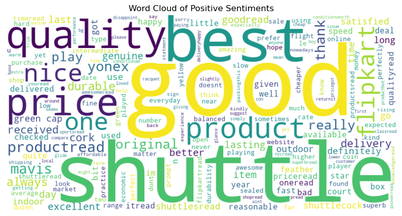

```python
from wordcloud import WordCloud
import matplotlib.pyplot as plt

# Filter positive sentiments and get normalized text
positive = df_rvw[df_rvw["SENTIMENT"] == "Positive"]["NORMALIZED_TEXT"]

# Take the first 100 positive reviews
positive_100 = positive.head(100)

# Join the text into a single string
positive_text = " ".join(positive_100)

# Generate the word cloud
wordcloud = WordCloud(width=800, height=400, background_color='white').generate(positive_text)

# Display the word cloud
plt.figure(figsize=(10, 6))
plt.imshow(wordcloud, interpolation='bilinear')
plt.title('Word Cloud of Positive Sentiments')
plt.axis('off')  # Hide axes
plt.show()
```

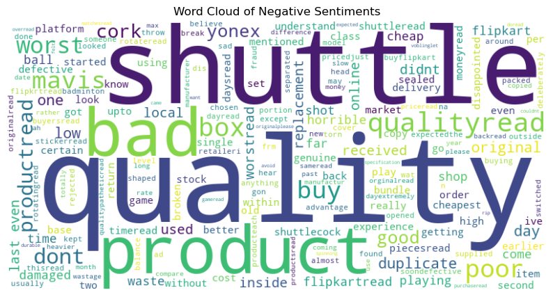

```python
from wordcloud import WordCloud
import matplotlib.pyplot as plt

# Filter positive sentiments and get normalized text
positive = df_rvw[df_rvw["SENTIMENT"] == "Negative"]["NORMALIZED_TEXT"]

# Take the first 100 positive reviews
positive_100 = positive.head(100)

# Join the text into a single string
positive_text = " ".join(positive_100)

# Generate the word cloud
wordcloud = WordCloud(width=800, height=400, background_color='white').generate(positive_text)

# Display the word cloud
plt.figure(figsize=(10, 6))
plt.imshow(wordcloud, interpolation='bilinear')
plt.title('Word Cloud of Negative Sentiments')
plt.axis('off')  # Hide axes
plt.show()
```

```python
from sklearn.preprocessing import LabelEncoder
import joblib

# Assuming 'labels' is your list of sentiment labels (positive, negative, neutral)
labels = ['positive', 'negative']

# Initialize LabelEncoder
label_encoder = LabelEncoder()

# Fit LabelEncoder to your list of labels
label_encoder.fit(labels)

# Save the label encoder to a pickle file
joblib.dump(label_encoder, 'label_encoder.pkl')
```

```
['label_encoder.pkl']
```

## Machine Learning Algorithms

### Logistic Regression:

- **Usage:** Logistic Regression is commonly used for binary classification tasks, where the target variable has two classes (e.g., yes/no, 0/1).
- **Explanation:** It's a simple yet effective algorithm that models the probability of the binary outcome using a logistic function. Logistic Regression works well when the relationship between the features and the target variable is approximately linear and the data is not highly complex.

### Support Vector Machine (SVC):

- **Usage:** SVC is suitable for both classification and regression tasks, especially when dealing with complex data and non-linear relationships.
- **Explanation:** SVC works by finding the hyperplane that best separates different classes in the feature space. It can handle high-dimensional data and is effective in cases where there is a clear margin of separation between classes.

### Random Forest:

- **Usage:** Random Forest is an ensemble method widely used for both classification and regression tasks, offering high accuracy and resistance to overfitting.
- **Explanation:** It builds multiple decision trees during training and combines their predictions through voting or averaging. Random Forest is robust to noisy data and outliers, making it suitable for diverse datasets.

### Multinomial Naive Bayes:

- **Usage:** Multinomial Naive Bayes is often used in text classification tasks, especially when dealing with multiple classes and discrete features (e.g., word counts).
- **Explanation:** It's based on Bayes' theorem with the assumption of independence between features. Multinomial Naive Bayes is efficient and scalable, making it suitable for large datasets with high dimensionality, such as text data.

### Bag-of-Words (BoW):

- **Usage:** BoW is a common text vectorization technique used in Natural Language Processing (NLP) tasks, including sentiment analysis and text classification.
- **Explanation:** BoW represents text data by counting the frequency of each word in the document. It disregards the order of words but captures their presence, making it suitable for tasks where word frequency is informative.

### TF-IDF (Term Frequency-Inverse Document Frequency):

- **Usage:** TF-IDF is another text vectorization method widely used in NLP tasks to represent the importance of words in documents.
- **Explanation:** TF-IDF assigns weights to words based on their frequency in the document and inverse frequency across all documents. It helps in identifying important and rare words that can be more informative for classification tasks.

```python
X = df_rvw["NORMALIZED_TEXT"]  # Use the feature matrix you want to train on (BoW, TF-IDF, Word2Vec)
y = df_rvw['SENTIMENT']
```

```python
X_train, X_test, y_train, y_test = train_test_split(X, y, test_size=0.2, random_state=42)
```

```python
df_rvw['SENTIMENT'].value_counts()
```

```
Positive    7437
Negative    1071
Name: SENTIMENT, dtype: int64
```

```python
X_train.shape
```

```
(6806,)
```

```python
import pandas as pd
from sklearn.model_selection import train_test_split, GridSearchCV
from sklearn.metrics import f1_score
from sklearn.linear_model import LogisticRegression
from sklearn.ensemble import RandomForestClassifier
from sklearn.svm import SVC
from sklearn.naive_bayes import MultinomialNB
from sklearn.feature_extraction.text import CountVectorizer, TfidfVectorizer
from sklearn.pipeline import Pipeline
import joblib
import time
import warnings

# Disable warnings
warnings.filterwarnings('ignore')

# Assuming X_train, X_test, y_train, y_test are already defined

# Define pipelines for each algorithm
pipelines = {
    'Logistic Regression': Pipeline([
        ('vectorization', CountVectorizer()),
        ('classifier', LogisticRegression())
    ]),
    'Random Forest': Pipeline([
        ('vectorization', CountVectorizer()),
        ('classifier', RandomForestClassifier())
    ]),
    'Support Vector Machine': Pipeline([
        ('vectorization', CountVectorizer()),
        ('classifier', SVC())
    ]),
    'Multinomial Naive Bayes': Pipeline([
        ('vectorization', CountVectorizer()),
        ('classifier', MultinomialNB())
    ]),
}

# Define parameter grids for each algorithm
param_grids = {
    'Logistic Regression': {
        'vectorization__max_features': [1000, 1500, 2000, 5000],
        'vectorization__ngram_range': [(1, 1), (1, 2)],
        'classifier__C': [0.1, 1, 10],
        'classifier__penalty': ['l1', 'l2']
    },
    'Random Forest': {
        'vectorization__max_features': [1000, 1500, 2000, 5000],
        'vectorization__ngram_range': [(1, 1), (1, 2)],
        'classifier__n_estimators': [50, 100, 200]
    },
    'Support Vector Machine': {
        'vectorization__max_features': [1000, 1500, 2000, 5000],
        'vectorization__ngram_range': [(1, 1), (1, 2)],
        'classifier__C': [0.1, 1, 10],
        'classifier__kernel': ['linear', 'rbf']
    },
    'Multinomial Naive Bayes': {
        'vectorization__max_features': [1000, 1500, 2000, 5000],
        'vectorization__ngram_range': [(1, 1), (1, 2)],
        'classifier__alpha': [0.1, 0.5, 1.0]
    },
}

# Create new dictionaries for TF-IDF pipelines and parameter grids
tfidf_pipelines = {}
tfidf_param_grids = {}

# Add TfidfVectorizer to pipelines and param_grids
for name, pipeline in pipelines.items():
    tfidf_pipeline = Pipeline([
        ('vectorization', TfidfVectorizer()),
        ('classifier', pipeline.named_steps['classifier'])
    ])
    tfidf_pipelines[name + ' (TF-IDF)'] = tfidf_pipeline

    param_grid = param_grids[name].copy()
    param_grid['vectorization__use_idf'] = [True, False]
    tfidf_param_grids[name + ' (TF-IDF)'] = param_grid

# Combine original pipelines and parameter grids with TF-IDF versions
pipelines.update(tfidf_pipelines)
param_grids.update(tfidf_param_grids)

# Perform GridSearchCV for each algorithm
best_models = {}

for model_name, pipeline in pipelines.items():
    print("*" * 10, model_name, "*" * 10)
    start_time = time.time()

    grid_search = GridSearchCV(estimator=pipeline,
                               param_grid=param_grids[model_name],
                               cv=5,
                               scoring='f1_weighted',
                               return_train_score=True,
                               verbose=1,
                               n_jobs=-1)  # Use all available CPU cores

    grid_search.fit(X_train, y_train)
    best_model = grid_search.best_estimator_
    best_models[model_name] = best_model

    # Calculate and print train and test accuracy
    train_score = grid_search.score(X_train, y_train)
    test_score = grid_search.score(X_test, y_test)
    print("Train Accuracy:", train_score)
    print("Test Accuracy:", test_score)

    end_time = time.time()
    print("Time taken:", end_time - start_time, "seconds")
```

```
********** Logistic Regression **********
Fitting 5 folds for each of 48 candidates, totalling 240 fits
Train Accuracy: 0.9351454575235595
Test Accuracy: 0.9169456589708491
Time taken: 18.980504751205444 seconds
********** Random Forest **********
Fitting 5 folds for each of 24 candidates, totalling 120 fits
Train Accuracy: 0.9756831849543156
Test Accuracy: 0.9068363443345447
Time taken: 856.6596248149872 seconds
********** Support Vector Machine **********
Fitting 5 folds for each of 48 candidates, totalling 240 fits
Train Accuracy: 0.9523429600758846
Test Accuracy: 0.9122091304741387
Time taken: 127.08492016792297 seconds
********** Multinomial Naive Bayes **********
Fitting 5 folds for each of 24 candidates, totalling 120 fits
Train Accuracy: 0.9500791883680879
Test Accuracy: 0.9107300148016876
Time taken: 9.20621395111084 seconds
********** Logistic Regression (TF-IDF) **********
Fitting 5 folds for each of 96 candidates, totalling 480 fits
Train Accuracy: 0.961615972474033
Test Accuracy: 0.9143067126669294
Time taken: 29.658601999282837 seconds
********** Random Forest (TF-IDF) **********
Fitting 5 folds for each of 48 candidates, totalling 240 fits
Train Accuracy: 0.9750691376192661
Test Accuracy: 0.906914012599876
Time taken: 613.5093162059784 seconds
********** Support Vector Machine (TF-IDF) **********
Fitting 5 folds for each of 96 candidates, totalling 480 fits
Train Accuracy: 0.9464877225031253
Test Accuracy: 0.9107424142770276
Time taken: 1536.8729186058044 seconds
********** Multinomial Naive Bayes (TF-IDF) **********
Fitting 5 folds for each of 48 candidates, totalling 240 fits
Train Accuracy: 0.9494991147836193
Test Accuracy: 0.9138263793660781
Time taken: 10.445114135742188 seconds
```

```python
import os
import joblib

# Define the path to the folder containing the saved models
drive_path =  "best_models/"

# Create a dictionary to store the loaded models
loaded_models = {}

# Loop through the files in the folder
for filename in os.listdir(drive_path):
    # Check if the file is a pickle file
    if filename.endswith(".pkl"):
        # Extract the model name from the file name
        model_name = os.path.splitext(filename)[0]
        # Load the model using joblib
        loaded_model = joblib.load(os.path.join(drive_path, filename))
        # Add the loaded model to the dictionary
        loaded_models[model_name] = loaded_model

# Display the loaded models
for name, model in loaded_models.items():
    print("*"*10, name, "*"*10)
    print(model)
    print()
```

```
********** Logistic Regression (TF-IDF) **********
Pipeline(steps=[('vectorization',
                 TfidfVectorizer(max_features=5000, ngram_range=(1, 2),
                                 use_idf=False)),
                ('classifier', LogisticRegression(C=10))])

********** Logistic Regression **********
Pipeline(steps=[('vectorization', CountVectorizer(max_features=5000)),
                ('classifier', LogisticRegression(C=1))])

********** Multinomial Naive Bayes (TF-IDF) **********
Pipeline(steps=[('vectorization',
                 TfidfVectorizer(max_features=2000, ngram_range=(1, 2),
                                 use_idf=False)),
                ('classifier', MultinomialNB(alpha=0.1))])

********** Multinomial Naive Bayes **********
Pipeline(steps=[('vectorization',
                 CountVectorizer(max_features=5000, ngram_range=(1, 2))),
                ('classifier', MultinomialNB(alpha=0.1))])

********** Random Forest (TF-IDF) **********
Pipeline(steps=[('vectorization', TfidfVectorizer(max_features=1500)),
                ('classifier', RandomForestClassifier(n_estimators=200))])

********** Random Forest **********
Pipeline(steps=[('vectorization', CountVectorizer(max_features=5000)),
                ('classifier', RandomForestClassifier())])

********** Support Vector Machine (TF-IDF) **********
Pipeline(steps=[('vectorization',
                 TfidfVectorizer(max_features=5000, use_idf=False)),
                ('classifier', SVC(C=10))])

********** Support Vector Machine **********
Pipeline(steps=[('vectorization', CountVectorizer(max_features=5000)),
                ('classifier', SVC(C=1, kernel='linear'))])
```

```python
import os
import joblib

# Define the directory path to save the models
local_path = "best_models/"
if not os.path.exists(local_path):
    os.makedirs(local_path)

# Save the best models
for name, model in best_models.items():
    joblib.dump(model, os.path.join(local_path, f'{name}.pkl'))

# Load the best models from the local directory
loaded_models = {}
for name in best_models.keys():
    loaded_model = joblib.load(os.path.join(local_path, f'{name}.pkl'))
    loaded_models[name] = loaded_model
    print("*"*10, name, "*"*10)

    # Making predictions on test data (assuming X_test and y_test are defined)
    y_test_pred = loaded_model.predict(X_test)

    # Calculating F1 score (assuming you have imported f1_score)
    f1 = f1_score(y_test, y_test_pred, average='weighted')
    print("Test Score (F1)", f1)

    # Getting model size
    print("Model Size:", os.path.getsize(os.path.join(local_path, f'{name}.pkl')), "Bytes")
```

```
********** Logistic Regression **********
Test Score (F1) 0.9169456589708491
Model Size: 78645 Bytes
********** Random Forest **********
Test Score (F1) 0.9068363443345447
Model Size: 16780826 Bytes
********** Support Vector Machine **********
Test Score (F1) 0.9122091304741387
Model Size: 204382 Bytes
********** Multinomial Naive Bayes **********
Test Score (F1) 0.9107300148016876
Model Size: 470679 Bytes
********** Logistic Regression (TF-IDF) **********
Test Score (F1) 0.9143067126669294
Model Size: 350979 Bytes
********** Random Forest (TF-IDF) **********
Test Score (F1) 0.906914012599876
Model Size: 6002465 Bytes
********** Support Vector Machine (TF-IDF) **********
Test Score (F1) 0.9107424142770276
Model Size: 305370 Bytes
********** Multinomial Naive Bayes (TF-IDF) **********
Test Score (F1) 0.9138263793660781
Model Size: 470784 Bytes
```

```python
import os
import joblib

# Define the directory path to save the models
local_path = "best_models/"
if not os.path.exists(local_path):
    os.makedirs(local_path)

# Save the best models
for name, model in best_models.items():
    joblib.dump(model, os.path.join(local_path, f'{name}.pkl'))

# Load the best models from the local directory
loaded_models = {}
for name in best_models.keys():
    loaded_model = joblib.load(os.path.join(local_path, f'{name}.pkl'))
    loaded_models[name] = loaded_model
    print("*"*10, name, "*"*10)
    sample_text =["Nice product, good quality, but price is now rising which is a bad sign. 800-850 was an affordable price, especially when we play everyday. So kindly help us out in terms of the price. Thank You.READ MORE"]
    # Making predictions on test data (assuming X_test and y_test are defined)
    y_test_pred = loaded_model.predict(sample_text)


    print("Test Score (F1)", y_test_pred)
```

```
********** Logistic Regression **********
Test Score (F1) ['Positive']
********** Random Forest **********
Test Score (F1) ['Positive']
********** Support Vector Machine **********
Test Score (F1) ['Positive']
********** Multinomial Naive Bayes **********
Test Score (F1) ['Positive']
********** Logistic Regression (TF-IDF) **********
Test Score (F1) ['Positive']
********** Random Forest (TF-IDF) **********
Test Score (F1) ['Positive']
********** Support Vector Machine (TF-IDF) **********
Test Score (F1) ['Positive']
********** Multinomial Naive Bayes (TF-IDF) **********
Test Score (F1) ['Positive']
```

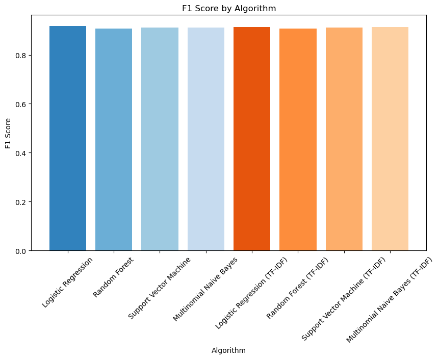

```python
plt.figure(figsize=(10, 6))
colors = plt.cm.tab20c.colors  # Using a colormap for distinct colors
plt.bar(results_df['Algorithm'], results_df['F1 Score'], color=colors)
plt.title('F1 Score by Algorithm')
plt.xlabel('Algorithm')
plt.xticks(rotation=45)
plt.ylabel('F1 Score')
plt.show()
```

```python
results_df
```

|  | Algorithm | F1 Score |
| --- | --- | --- |
| 0 | Logistic Regression | 0.916946 |
| 1 | Random Forest | 0.906836 |
| 2 | Support Vector Machine | 0.912209 |
| 3 | Multinomial Naive Bayes | 0.910730 |
| 4 | Logistic Regression (TF-IDF) | 0.914307 |
| 5 | Random Forest (TF-IDF) | 0.906914 |
| 6 | Support Vector Machine (TF-IDF) | 0.910742 |
| 7 | Multinomial Naive Bayes (TF-IDF) | 0.913826 |

### Logistic Regression (TF-IDF):

- F1 Score: 0.914307
- Using TF-IDF vectorization with a maximum of 5000 features, ngram_range of (1, 2), and no inverse document frequency weighting, the logistic regression model achieved an F1 score of approximately 0.9143. ### Logistic Regression:
- F1 Score: 0.916946
- Using Count Vectorization with a maximum of 5000 features, the logistic regression model achieved a slightly higher F1 score of approximately 0.9169 compared to the TF-IDF version. ### Multinomial Naive Bayes (TF-IDF):
- F1 Score: 0.913826
- Employing TF-IDF vectorization with a maximum of 2000 features, ngram_range of (1, 2), and alpha value of 0.1, the Multinomial Naive Bayes classifier attained an F1 score of around 0.9138. ### Multinomial Naive Bayes:
- F1 Score: 0.910730
- Utilizing Count Vectorization with a maximum of 5000 features and ngram_range of (1, 2), the Multinomial Naive Bayes model achieved an F1 score of approximately 0.9107. ### Random Forest (TF-IDF):
- F1 Score: 0.906914
- Using TF-IDF vectorization with a maximum of 1500 features and 200 estimators, the Random Forest classifier achieved an F1 score of about 0.9069. ### Random Forest:
- F1 Score: 0.906836
- Employing Count Vectorization with a maximum of 5000 features and default parameters for the Random Forest classifier resulted in an F1 score of approximately 0.9068. ### Support Vector Machine (TF-IDF):
- F1 Score: 0.910742
- Using TF-IDF vectorization with a maximum of 5000 features and C value of 10, the Support Vector Machine classifier achieved an F1 score of around 0.9107. ### Support Vector Machine:
- F1 Score: 0.912209
- Employing Count Vectorization with a maximum of 5000 features and a linear kernel with C value of 1 for the Support Vector Machine model resulted in an F1 score of approximately 0.9122.

## DEEP LEARNING

```python
import tensorflow as tf
from tensorflow.keras.layers import Embedding, LSTM, Dense, Dropout
from tensorflow.keras.models import Sequential
from sklearn.base import BaseEstimator, ClassifierMixin
from sklearn.metrics import f1_score
from tensorflow.keras.preprocessing.sequence import pad_sequences
from sklearn.preprocessing import LabelEncoder
import numpy as np

# Define a custom Keras classifier
class CustomKerasClassifier(BaseEstimator, ClassifierMixin):
    def __init__(self, units=128, dropout_rate=0.2, recurrent_dropout=0.2, dense_units=64, epochs=10, batch_size=32):
        self.units = units
        self.dropout_rate = dropout_rate
        self.recurrent_dropout = recurrent_dropout
        self.dense_units = dense_units
        self.epochs = epochs
        self.batch_size = batch_size
        self.model = None
        self.tokenizer = None
        self.label_encoder = None

    def fit(self, X, y):
        # Tokenize and pad sequences
        self.tokenizer = tf.keras.preprocessing.text.Tokenizer()
        self.tokenizer.fit_on_texts(X)
        X_seq = self.tokenizer.texts_to_sequences(X)
        max_len = max(len(seq) for seq in X_seq)
        X_pad = pad_sequences(X_seq, maxlen=max_len, padding='post')

        # Encode labels
        self.label_encoder = LabelEncoder()
        y_enc = self.label_encoder.fit_transform(y)

        # Define the model
        self.model = Sequential([
            Embedding(input_dim=len(self.tokenizer.word_index) + 1, output_dim=128),
            LSTM(units=self.units, dropout=self.dropout_rate, recurrent_dropout=self.recurrent_dropout),
            Dense(units=self.dense_units, activation='relu'),
            Dropout(0.2),
            Dense(units=np.max(y_enc) + 1, activation='softmax')  # Adjust output units based on classes
        ])
        self.model.compile(optimizer='adam', loss='sparse_categorical_crossentropy', metrics=['accuracy'])

        # Train the model
        self.model.fit(X_pad, y_enc, epochs=self.epochs, batch_size=self.batch_size, verbose=0)

        return self

    def predict(self, X):
        # Tokenize and pad sequences for prediction
        X_seq = self.tokenizer.texts_to_sequences(X)
        max_len = max(len(seq) for seq in X_seq)
        X_pad = pad_sequences(X_seq, maxlen=max_len, padding='post')

        # Make predictions
        y_pred = self.model.predict(X_pad)
        y_pred_labels = np.argmax(y_pred, axis=1)
        y_pred_decoded = self.label_encoder.inverse_transform(y_pred_labels)

        return y_pred_decoded

# Assuming X_train, X_test, y_train, y_test are already defined

# Create a custom Keras classifier
custom_model = CustomKerasClassifier()

# Fit the model
custom_model.fit(X_train, y_train)

# Evaluate the model
y_pred = custom_model.predict(X_test)
test_f1 = f1_score(y_test, y_pred, average='weighted')
print(f'Test F1 Score: {test_f1}')
```

```
54/54 ━━━━━━━━━━━━━━━━━━━━ 2s 25ms/step
Test F1 Score: 0.8181384587245233
```